# Assignment 5

In this assignment, you'll scrape text from [The California Aggie](https://theaggie.org/) and then analyze the text.

The Aggie is organized by category into article lists. For example, there's a [Campus News](https://theaggie.org/campus/) list, [Arts & Culture](https://theaggie.org/arts/) list, and [Sports](https://theaggie.org/sports/) list. Notice that each list has multiple pages, with a maximum of 15 articles per page.

The goal of exercises 1.1 - 1.3 is to scrape articles from the Aggie for analysis in exercise 1.4.

**Exercise 1.1.** Write a function that extracts all of the links to articles in an Aggie article list. The function should:

- Have a parameter `url` for the URL of the article list.
- Have a parameter `page` for the number of pages to fetch links from. The default should be `1`.
- Return a list of aricle URLs (each URL should be a string).

Test your function on 2-3 different categories to make sure it works.

Hints:

- Be polite to The Aggie and save time by setting up [requests_cache](https://pypi.python.org/pypi/requests-cache) before you write your function.
- Start by getting your function to work for just 1 page. Once that works, have your function call itself to get additional pages.
- You can use [lxml.html](http://lxml.de/lxmlhtml.html) or [BeautifulSoup](https://www.crummy.com/software/BeautifulSoup/bs4/doc/) to scrape HTML. Choose one and use it throughout the entire assignment.

```python
import requests_cache
from bs4 import BeautifulSoup
import requests
import lxml
import pandas as pd

requests_cache.install_cache('demo_cache')

def extract_url(url, numpages = 1): #extrcct url using requests.get,
    if numpages == 0:
        return []
    results = []
    url2 = url + 'page/' + str(numpages) + '/'
    response = requests.get(url2)
    soup1 = BeautifulSoup(response.text, 'html.parser')

    for heads in soup1.find_all(attrs = {'class' : 'entry-title'}): #for loop to grab each link under a tag and class entry-title
        for link in heads.find_all('a'):
            results.append(str(link.get('href')))

    results.extend(extract_url(url,numpages-1)) #ran recursive function to call itself until numpages satisfied
    return results

extract_url("https://theaggie.org/arts/", 4)
```

```
['https://theaggie.org/2017/02/13/burning-love-parody-of-the-bachelor/',
 'https://theaggie.org/2017/02/12/the-bachelor-engages-viewers-prompts-viewing-rituals/',
 'https://theaggie.org/2017/02/12/seven-movies-from-the-seven-countries-targeted-by-president-trumps-muslim-ban/',
 'https://theaggie.org/2017/02/12/the-best-of-times-and-the-worst-of-times-a-valentines-day-playlist/',
 'https://theaggie.org/2017/02/09/events-calendar-for-february/',
 'https://theaggie.org/2017/02/09/hopped-up-comedy-x-arrives-in-time-for-valentines-day-weekend/',
 'https://theaggie.org/2017/02/09/lantern-festival-the-beginning-of-the-year/',
 'https://theaggie.org/2017/02/07/top-three-places-to-eat-when-hungover/',
 'https://theaggie.org/2017/02/06/dance-dance/',
 'https://theaggie.org/2017/02/06/skams-universal-appeal/',
 'https://theaggie.org/2017/02/06/t-v-revisited-breaking-bad/',
 'https://theaggie.org/2017/02/02/headline-a-look-inside-kdvs/',
 'https://theaggie.org/2017/02/02/spoken-word-allows-for-expression-of-much-more-than-words/',
 'https://theaggie.org/2017/02/02/the-self-proclaimed-cure-for-racism/',
 'https://theaggie.org/2017/02/02/a-feast-for-the-ears-just-in-time-for-lunch/',
 'https://theaggie.org/2017/02/27/oscars-shift-to-diversity-not-enough/',
 'https://theaggie.org/2017/02/27/third-space-art-collective-ordered-to-vacate-premises/',
 'https://theaggie.org/2017/02/26/getting-crafty-in-central-park/',
 'https://theaggie.org/2017/02/26/fun-arts-and-culture-classes-to-take-in-the-spring/',
 'https://theaggie.org/2017/02/23/sacramentos-artstreet-exhibit-showcases-diverse-artwork/',
 'https://theaggie.org/2017/02/23/armadillo-kdvs-collaborate-to-host-vinyl-and-music-fair/',
 'https://theaggie.org/2017/02/23/harlows-nightclub-presents-khalid/',
 'https://theaggie.org/2017/02/21/late-night-eats-in-davis/',
 'https://theaggie.org/2017/02/21/2017-oscar-nominations-and-predictions/',
 'https://theaggie.org/2017/02/20/student-sounds-samantha-sipin/',
 'https://theaggie.org/2017/02/20/tv-revisited-the-office/',
 'https://theaggie.org/2017/02/19/uc-davis-theater-and-dance-presents-its-newest-comedy/',
 'https://theaggie.org/2017/02/19/twenty-one-pilots-emotional-roadshow-world-tour/',
 'https://theaggie.org/2017/02/16/a-night-under-the-stars/',
 'https://theaggie.org/2017/02/14/critically-acclaimed-stand-up-comic-brian-regan-to-perform-at-mondavi-center/',
 'https://theaggie.org/2017/03/16/local-venues-host-wine-and-painting-classes/',
 'https://theaggie.org/2017/03/15/the-magic-of-pippin/',
 'https://theaggie.org/2017/03/14/design-matters-a-look-inside-the-turtle-house/',
 'https://theaggie.org/2017/03/13/davis-alumna-presents-art-exhibit-inspired-by-womens-rights/',
 'https://theaggie.org/2017/03/13/design-majors-international-living-experiences-inspire-creativity/',
 'https://theaggie.org/2017/03/12/a-review-disneys-live-action-beauty-and-the-beast/',
 'https://theaggie.org/2017/03/10/jose-gonzalez-delivers-multi-dimensional-musical-experience/',
 'https://theaggie.org/2017/03/07/going-baroque/',
 'https://theaggie.org/2017/03/06/writers-pick-podcasts-ive-been-listening-to/',
 'https://theaggie.org/2017/03/05/the-lounge-lizards-present-no-instruments-attached-2/',
 'https://theaggie.org/2017/03/05/three-generations-of-rockers-a-review-of-the-hendrix-experience/',
 'https://theaggie.org/2017/03/05/aggie-style-watch-surviving-the-winter/',
 'https://theaggie.org/2017/03/02/events-calendar-for-march/',
 'https://theaggie.org/2017/02/28/rainy-day-commute-playlist/',
 'https://theaggie.org/2017/02/28/3rd-thursdays-at-the-shrem/',
 'https://theaggie.org/2017/04/13/end-of-april-events-calendar/',
 'https://theaggie.org/2017/04/13/camped-streetwear-club-to-present-night-of-hip-hop-entertainment/',
 'https://theaggie.org/2017/04/11/three-documentaries-to-break-your-tv-rut/',
 'https://theaggie.org/2017/04/11/a-quarter-of-concerts/',
 'https://theaggie.org/2017/04/10/hidden-artistic-talents-of-the-uc-davis-mens-basketball-team/',
 'https://theaggie.org/2017/04/09/spring-quad-playlist/',
 'https://theaggie.org/2017/04/09/tea-4-u-the-newest-addition-to-the-davis-boba-scene/',
 'https://theaggie.org/2017/04/06/sudwerk-brewery-bakuhatsu-taiko-dan-host-cherry-blossom-festival/',
 'https://theaggie.org/2017/04/06/culture-co-op-presents-second-annual-we-all-have-a-heritage-showcase/',
 'https://theaggie.org/2017/03/21/the-resurgence-of-political-comedy/',
 'https://theaggie.org/2017/03/21/vegan-eats-at-the-coho/',
 'https://theaggie.org/2017/03/20/liquid-hotplates-take-home-first-place-in-a-cappella-competition/',
 'https://theaggie.org/2017/03/19/uc-davis-basement-gallery-hosts-exhibition-dedicated-to-international-womens-day/',
 'https://theaggie.org/2017/03/19/finals-motivation-playlist/',
 'https://theaggie.org/2017/03/19/seeking-advice-check-out-this-weeks-horoscope/']
```

Write a function that extracts the title, text, and author of an Aggie article. The function should:

- Have a parameter `url` for the URL of the article.
- For the author, extract the "Written By" line that appears at the end of most articles. You don't have to extract the author's name from this line.
- Return a dictionary with keys "url", "title", "text", and "author". The values for these should be the article url, title, text, and author, respectively.

```python
#     Return a dictionary with keys "url", "title", "text", and "author". The values for these should
#     be the article url, title, text, and author, respectively

def extracts(article_url): #takes in an article url as a param
    article = requests.get(article_url)
    soup = BeautifulSoup(article.text, 'html.parser') #used beautiful soup html.parser
    totranslate ={0x2013:0x82, 0x2014:0x45, 0x2018:0x27, 0x2019:0x27, 0x275D:0x22, 0x275E:0x22, 0x0022:0x22, 0x201C:0x22, 0x201D:0x22, 0x2026:0x20}
    stuff = {}

    #found that author was stored in itemprop 'articlebody' under p tag and it was at the last line of the last paragraph
    #though i could not find ALL of the authors :[, i used james's hint... please don't dock me off for that
    finalpara = soup.body.find(itemprop = 'articleBody').find_all('p')[-1]
    author = finalpara.get_text().split('\n')[-1]

    texted = ''
    for texts in soup.find_all('p')[:-2]: #again text is under ptag up till the 2nd to last one and i translate unicode
        texts.get_text()
        texted = texted + texts.get_text()
    texted = texted.translate(totranslate)

    title = soup.title.string #title here always carries the  '| The Aggie' so i found that was the simplest way to retrieve
                                # a title from an article on the aggie ONLY
    title = str(title.translate(totranslate)).replace(" | The Aggie", '')
    stuff.update({'author' : author, 'text' : texted,'title' : title, 'url' : article_url})
    return stuff #returned a huge dictionary of the stuff i retrieved from each article link

extracts('https://theaggie.org/2017/01/12/police-logs-7/')
```

```
{'author': u'Written by: Sam Solomon\xa0\u2014\xa0city@theaggie.org',
 'text': u'Season\'s Greetings EditionDec. 24"Downstairs neighbor tapping on RP\'s floor"Dec. 25"Two intoxicated males \'sitting in RP\'s planter boxes\'"Dec. 25"Motorola walkie found"Dec. 25"Guest currently walking around naked"Dec. 26"RP saw someone in front yard stealing plants"Dec. 27"Bundle of …
 'title': 'Police Logs',
 'url': 'https://theaggie.org/2017/01/12/police-logs-7/'}
```

I used the functions created to get a data frame of 60 [Campus News](https://theaggie.org/campus/) articles and a data frame of 60 [City News](https://theaggie.org/city/) articles. Added a column to each that indicates the category, then combine them into one big data frame.

```python
campusurl = "https://theaggie.org/campus/"
cityurl = 'https://theaggie.org/city/'
campuslinks = extract_url(campusurl, 4) #extracted 60 urls from campus and city news sites
citylinks = extract_url(cityurl, 4)

campusstuff = [extracts(campuslink) for campuslink in campuslinks] #list comp to retrieve stuff form all of the sites using extracts
citystuff = [extracts(citylink) for citylink in citylinks]
```

```python
campusdf = pd.DataFrame(campusstuff)
campusdf['article type'] = 'campus' #new colname article type to differentiate between types of article
citydf = pd.DataFrame(citystuff)
citydf['article type'] = 'city'

ayedf = pd.concat([campusdf,citydf]) #combined two dataframe together to do tfidf transform later on
campusdf.head()
```

[output not shown]

```python
ayedf[98:99]
```

[output not shown]

Then I used the Aggie corpus to answer the following questions and used plots to support my analysis!

- What topics does the Aggie cover the most? Do city articles typically cover different topics than campus articles?
- What are the titles of the top 3 pairs of most similar articles? Examine each pair of articles. What words do they have in common?
- Do you think this corpus is representative of the Aggie? Why or why not? What kinds of inference can this corpus support? Explain your reasoning.

```python
import numpy as np
import nltk
import re
from nltk.stem.porter import PorterStemmer
from sklearn.feature_extraction.text import TfidfVectorizer
from sklearn.neighbors import NearestNeighbors
from matplotlib import pyplot as plt
from nltk.corpus import stopwords
import string
from string import maketrans
import operator
plt.style.use('ggplot')
%matplotlib inline
```

```python
###### tf-idf

# here i mainly used the code given in lesson 11 by professor sharpnack for a stem and lemmatize function for my tokens
stemmer = PorterStemmer().stem
tokenize = nltk.word_tokenize

def stem(tokens,stemmer = PorterStemmer().stem):
    return [stemmer(w.lower()) for w in tokens]

def lemmatize(text):
    """
    Extract simple lemmas based on tokenization and stemming
    Input: string
    Output: list of strings (lemmata)
    """
    return stem(tokenize(text))

def get_corpus(df): #to retrieve the corpus in a given data frame of t
    listofstuff = []
    for stuff in df['text']: #iterate through each text
        translate_table = dict((ord(char), None) for char in string.punctuation) #had to create a trans table in order for string.translate to work for unicode
        listofstuff.append(stuff.translate(translate_table)) #thank you stack over flow^^
    return listofstuff #returned as list

def get_title(df): #to retrieve the title of the article, useful later on
    listoftitles = []
    for titles in df['title']: #iterate through each title in the dataframe
        listoftitles.append(titles)
    return listoftitles #returned list of titles
```

```python
def plotfreqwords(df, colname):
    catwords = ''
    for cat in df[colname]:
        catwords = catwords + cat
    catwords = catwords.lower()
    listwords = lemmatize(catwords)
    listword_ss = [word for word in listwords if word not in stopwords.words('english')]
    listword_ss = [w for w in listword_ss if w not in string.punctuation]
    listword_ss = [w for w in listword_ss if w not in ['e',"'s", "n't","``",'one','also','said','"']]

    fd = nltk.FreqDist(listword_ss)
    return fd.plot(30, cumulative = False)
```

## Frequency Distribution Plot of top 30 Words in Campus News

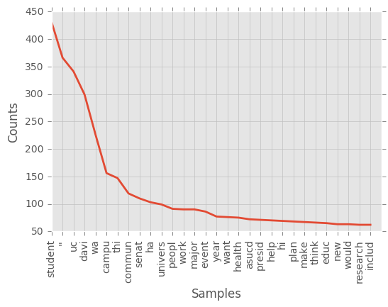

```python
plotfreqwords(campusdf,'text')
```

## Frequency Distribution Plot of top 30 Words in City News

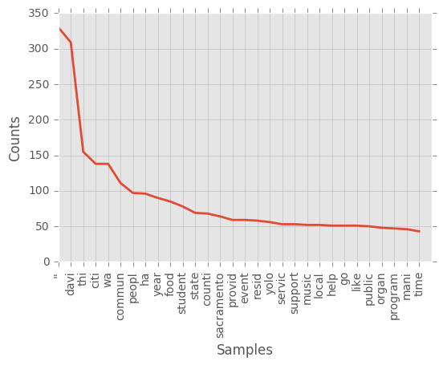

```python
plotfreqwords(citydf,'text')
```

## Frequency Distribution Plot of top 30 Words in Both Types of Articles

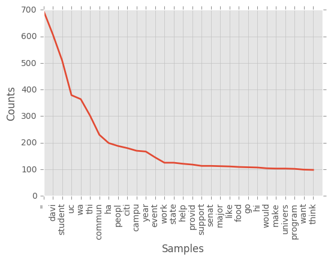

```python
plotfreqwords(ayedf,'text')
```

It can be seen that by comparing the two articles (and disregarding the trollish quotation mark please) are most focused on topics concerning Davis, UC Davis and students. This should not come as a surprise. The next words most used are people, community and events. Other interesting words to point out food, this is perhaps because of the city of Davis' lust for a meal that can quench any appetite. Another interesting word is state, perhaps topics that cover state include things like state tuition, or politics.  
However, this alone is not sufficient information as to which articles have more similarity to one another. So I decided to do a tf-idf transform to get the 3 pairs of most similar articles.

```python
def sims_scores(df):
    vectorizer = TfidfVectorizer(tokenizer=lemmatize,stop_words="english",smooth_idf=True, norm = 'l1') #used in lesson 11 by james
    tfs = vectorizer.fit_transform(get_corpus(df)) # lesson 11
    sim_m = tfs1.dot(tfs1.T) # dot product of tfs and tfs transpose to create a similarity matrix with the scores to the right column
    sim = sim_m.toarray() #converted to a numpy array
    ayelmao = np.argsort(sim) #sorted the array by scores, ascending~~

    setsofarticles = []
    for aye in xrange(len(ayelmao)): #iterate through the array of articles
        setsofarticles.append((ayelmao[aye][-2],ayelmao[aye][-1])) #created list of tuples, articles inside tuples
                                                                    #last articles retrieved, they have the highest sim score for the given array

    realsimscores = {} # empty dict
    for tupe in setsofarticles: #iterate through list of the tuples
        realsimscores.update({tupe:sim_m[(tupe)]}) #update the article with a specified score

    for tupe in realsimscores.keys(): #iterate each article pair
        x,y = tupe
        if abs(x-y) < 60: #make sure that they are of different types man!!!!!!!!!!!! (city va campus)
            realsimscores.pop((x,y), None)
    return realsimscores #returns the scores from the similarity matrix that only compares 2 articles of different types

def top_3_scores(df): #takes in a df and column name
    topscores = sims_scores(df) #calls sims_scores
    sort_topscores = sorted(topscores.items(), key=operator.itemgetter(1)) #sort the dictionary by the top scores
    top3 = sort_topscores[-3:] #retrieve top 3
    campusnames = []
    citynames = []
    for tupes in top3: #retrieved the title name of each article
        articles,score = tupes
        art1,art2 = articles
        title1 = get_title(df)[art1]
        title2 = get_title(df)[art2]
        campusnames.append(title1)
        citynames.append(title2)
    print 'Top 3 Articles with Highest Similarity Score! \n'
    for i in xrange(len(campusnames)): #to make it look relatively better
        print 'Campus Article: ',campusnames[i]
        print 'City Article: ', citynames[i]
        print '\n'

    return None
```

```python
top_3_scores(ayedf) #here gives the top 3 matching articles with highest scores
```

```
Top 3 Articles with Highest Similarity Score!

Campus Article:  Former chancellor turns down feminist leadership role at UC Davis
City Article:  Thousands gather at Sacramento Capitol building for women's rights


Campus Article:  Student regent recruitment for the 2018-2019 school year begins
City Article:  Construction of the All Student Center at Davis High begins


Campus Article:  Muslim students respond to recent political events
City Article:  Islamic Center of Davis victim of hate crime
```

Below, I plotted a side by side comparison of the different words that apprear in each article of the top 3 matching article pairs. Again the top will be **campus articles** and the bottom plots will be **city articles**. Here you can see which words that had most in common.

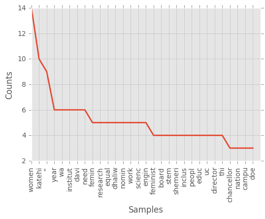

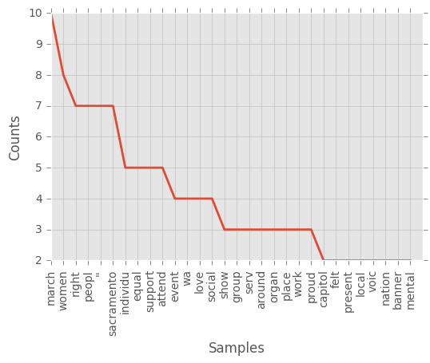

```python
top3 = [(1,98),(10,74),(36,99)] #top 3 pairs of articles

plotfreqwords(ayedf[1:2], 'text')
plotfreqwords(ayedf[98:99],'text')
```

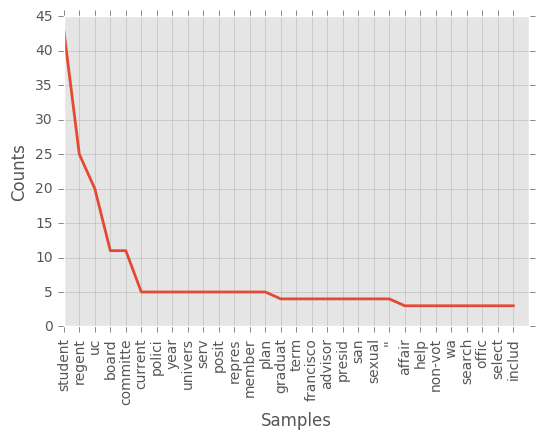

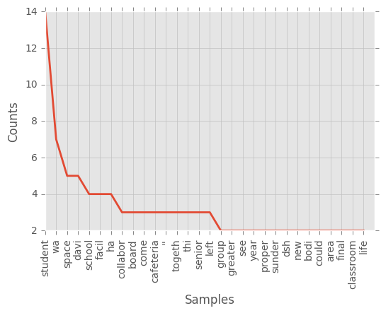

```python
plotfreqwords(ayedf[10:11], 'text')

plotfreqwords(ayedf[74:75],'text')
```

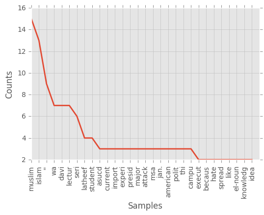

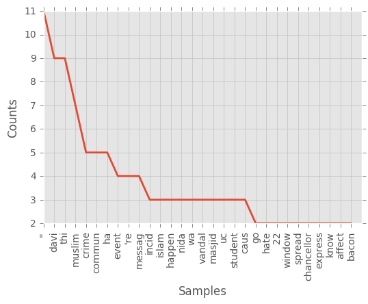

```python
plotfreqwords(ayedf[36:37], 'text')

plotfreqwords(ayedf[99:100],'text')
```

Yes, I believe this corpus is a representative of the Aggie, it holds many of the current issues accountable. with articles from both city and campus news talking about the chancelor problems and women's rights in Sac, from the first pair of articles. Also about the current racial threats and acts of terrorism towards the muslim minority (as seen in the 3rd pair of articles). Whereas the second pair of articles, students is the main focus here, talking about students whether from the high school or University seems to be one of the Aggie's topic of choice. Though of course we are leaving out here the many other kinds of articles the Aggie has to offer, such as sports articles, performing arts articles and etcetra. Overall, with the articles I analyzed I can conclude that this corpus is in fact an accurate representation of the Aggie, even without certain types of articles.